# PROJET: tuberculose

On observe également des différences : en 1990, il y a une certaine proximité entre les classes 1 et 2, avec un chevauchement visible, surtout pour les points de la classe 2. En 2000, bien que la séparation des classes soit présente, le chevauchement devient plus perceptible sur Dim2, ce qui montre une légère évolution de la répartition. En 2013, les classes sont largement séparées sur Dim1, la distinction entre les groupes est clairement marquée, et Dim2 semble moins influent pour cette séparation.

En somme, les classes 1 et 2 montrent des similitudes générales d’une année à l’autre, mais leur séparation se renforce au fil du temps, surtout entre 1990 et 2013. La période 2013 se distingue comme celle où les groupes sont les plus différenciés, avec des influences plus prononcées sur Dim1. Cela suggère que des facteurs temporels ont affecté l’évolution de ces classes, avec des variations plus marquées entre elles dans les années récentes.

Cela suggère que la dynamique des groupes a évolué au cours de cette période, avec une séparation plus nette entre les deux classes vers la fin de la période (2013).

Comparaison des visualisations des clusters sur CP1-CP3 : 3 classes

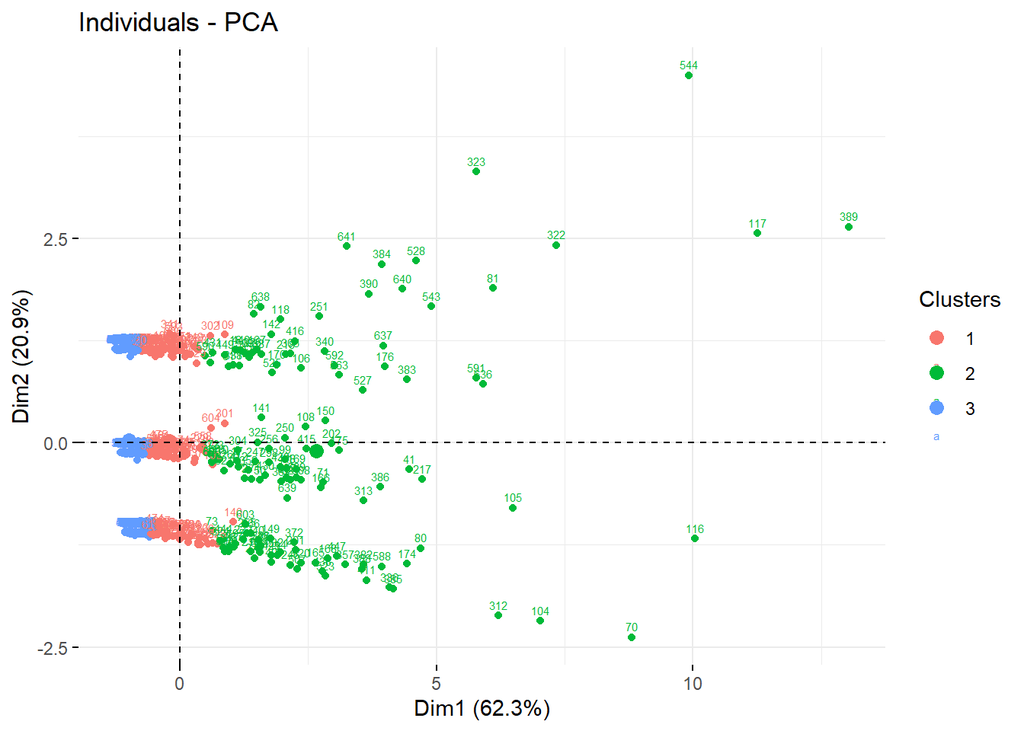

```r
fviz_pca_ind(res.pca.comparaison, # Utilisation des résultats de PCA précédemment calculés

             geom.ind = c("point", "text"), # Affichage des points et des étiquettes (noms des individus) sur le graphique

             labelsize = 2,  # Taille de la police pour les étiquettes des individus

             col.ind =TB2_ACP_comparaison2$labels3_2,    # Attribution des couleurs en fonction de label3_2

              pointshape = 19,  #rond plein
             legend.title = "Clusters") #titre
```

Le graphique montre la répartition des individus dans le plan des deux premières composantes principales (Dim1 et Dim2), avec les groupes colorés selon le clustering en trois classes.

Cela reflète l’impact du temps sur les tendances des groupes et montre comment les caractéristiques des pays se sont mieux distinguées au cours de cette période de 1990 à 2013. On remarque que peu importe l’année, on a à peu près les mêmes tendances.

##comparaison des visualisations des clusters sur CP1-CP4 : 4 classes

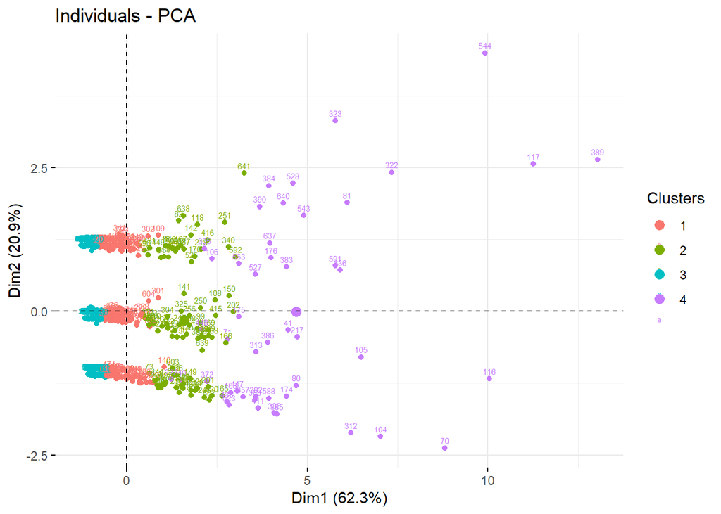

```r
fviz_pca_ind(res.pca.comparaison, # Utilisation des résultats de PCA précédemment calculés

             geom.ind = c("point", "text"), # Affichage des points et des étiquettes (noms des individus) sur le graphique

             labelsize = 2,  # Taille de la police pour les étiquettes des individus

             col.ind =TB2_ACP_comparaison2$labels4_2,   # Attribution des couleurs en fonction de  label4_2

              pointshape = 19, # point rond plein

             legend.title = "Clusters") #totre légende
```

Ainsi, on observe environ les mêmes dynamiques pour ces trois périodes différentes, témoignant que les différences du traitement sanitaire entre les pays développés et sous développé est à peu près le même depuis 1990 jusqu’à 2013.

##III.3) Methode K-means : Année 2000

Maintenant, nous allons passer à la méthode de K-means :

K-Means que pour l’année 2000

```r
kmeans(TB2_ACP_2000[,3:7], centers = 2)
```

```
## K-means clustering with 2 clusters of sizes 51, 161
##
## Cluster means:
##   Year Estimated_prevalence Mortalite_sans_VIH Mortalite_avec_VIH
## 1 2000            612.66667          69.368627          61.400784
## 2 2000             84.14534           7.019068           1.781863
##   Estimated_incidence
## 1           428.05882
## 2            57.89441
##
## Clustering vector:
##   [1] 1 2 2 2 2 1 2 2 2 2 2 2 2 1 2 2 1 2 2 2 2 2 2 1 2 2 1 2 2 2 2 2 1 2 1 1 2
##  [38] 2 1 2 2 2 2 2 2 2 1 2 2 1 2 2 2 2 1 1 2 1 2 2 2 2 2 2 2 2 1 2 2 2 2 1 2 1
##  [75] 2 2 2 2 2 2 2 1 1 2 1 2 2 2 1 1 2 2 2 2 2 2 2 2 1 2 1 2 1 1 2 2 1 1 2 2 2
## [112] 1 1 2 2 2 2 2 1 2 2 1 2 1 2 2 1 1 1 2 2 2 2 2 2 2 2 1 2 2 2 2 1 2 2 1 2 2
## [149] 1 2 2 2 2 2 2 2 2 2 2 2 2 2 2 2 2 2 2 2 1 2 2 2 2 1 1 2 2 2 2 1 2 2 2 1 2
## [186] 2 2 2 2 2 2 2 1 2 1 1 2 2 2 2 2 2 2 2 2 2 2 2 2 2 1 1
##
## Within cluster sum of squares by cluster:
## [1] 8679811 1727357
##  (between_SS / total_SS =  61.2 %)
##
## Available components:
##
## [1] "cluster"      "centers"      "totss"        "withinss"     "tot.withinss"
## [6] "betweenss"    "size"         "iter"         "ifault"
```

Comme on ne peut pas comprendre directement à quoi correspond le clustering vector, on va créer par la suite des tableau où l’on vera direcetment le nom des pays associer aux groupes

###Diagramme d’inertie K-means

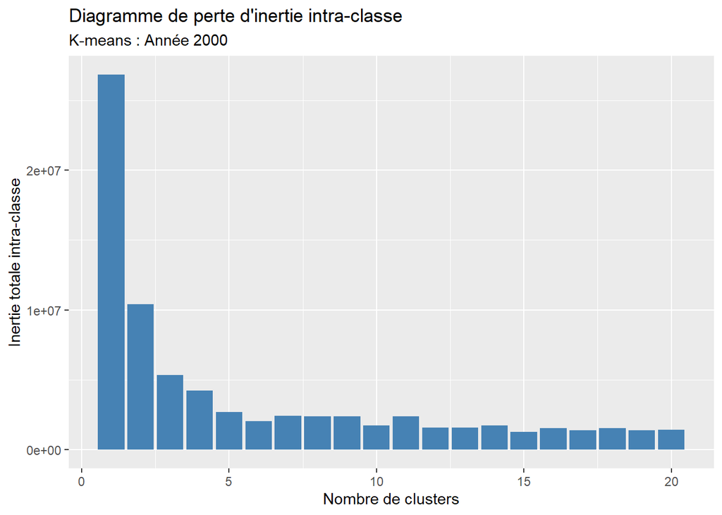

```r
K = 20 # Définir la valeur de K pour tester différents nombres de clusters (de 1 à 20)

wss <- c(1:K)  # Initialiser un vecteur vide pour stocker l'inertie intra-classe pour chaque valeur de K

# Calculer l'inertie intra-classe (withinss) pour chaque nombre de clusters de 1 à K
for (k in 1:K) {
  wss[k] <- sum(kmeans(TB2_ACP_2000[, 3:7], centers = k)$withinss) # À chaque itération, effectuer un clustering K-means avec k clusters (centers = k)
}

# Créer un graphique avec ggplot pour visualiser l'inertie intra-classe en fonction du nombre de clusters
ggplot(tibble(
  x = c(1:K),  # Crée un vecteur x allant de 1 à K (les différents nombres de clusters)
  y = wss      # Associe l'inertie intra-classe pour chaque nombre de clusters
)) +
  aes(x = x, y = y) + # Associe les variables x (nombre de clusters) et y (inertie totale intra-classe)

  # Créer un diagramme en barres pour afficher l'inertie
  geom_bar(
    stat = "identity",  # 'identity' signifie que la hauteur des barres sera directement déterminée par les valeurs de y
    fill = "steelblue"  # Couleur des barres (bleu acier)
  ) +

  labs(
    title = "Diagramme de perte d'inertie intra-classe", # titre
    subtitle = "K-means : Année 2000", # sous titre
    x = "Nombre de clusters", # titre de l'axe x
    y = "Inertie totale intra-classe" # titre de l'axe y
  )
```

Pour rappel, l’inertie mesure la dispersion des points au sein de chaque classe : plus elle est faible, plus les points à l’intérieur d’une classe sont proches les uns des autres.

L’analyse montre une diminution rapide de l’inertie totale intra-classes au fur et à mesure que le nombre de classes augmente. Cette réduction est marquée après la première ou deuxième classe, ce qui suggère qu’un petit nombre de classes permet déjà une bonne séparation des points. Au-delà de 3-4 classes, l’inertie continue de diminuer de manière plus progressive, ce qui indique qu’ajouter des classes supplémentaires n’améliore que marginalement la dispersion intra-classe.

Nous allons maintenant explorer les groupes pour les 4 classes et examiner les plans par individus car au-delà de ce nombre, les ajouts de clusters ne sont plus pertinents ni optimaux.

###Visualisation avec l’ACP K-means

Nous allons créer des étiquettes pour chaque nombre de clusters, puis générer une table pour visualiser les résultats de l’Analyse en Composantes Principales (ACP).

Pour cela, nous appliquons l’algorithme K-means sur les variables sélectionnées (colonnes 3 à 7 de TB2_ACP_2000), en fixant respectivement le nombre de clusters à 2, 3 et 4, et nous stockons les résultats dans les variables labels2.km, labels3.km et labels4.km :

```r
labels2.km <- kmeans(TB2_ACP_2000[,3:7], centers = 2)$cluster
labels3.km<- kmeans(TB2_ACP_2000[,3:7], centers = 3)$cluster
labels4.km <- kmeans(TB2_ACP_2000[,3:7], centers = 4)$cluster
```

Ensuite, nous créons un nouveau tableau TB2_ACP_2000_2.km qui contient les données des colonnes 3 à 7, ainsi que les étiquettes des clusters obtenues pour 2, 3 et 4 clusters. Nous convertissons les labels en caractères pour faciliter leur manipulation dans l’ACP :

```r
TB2_ACP_2000_2.km<- as.data.frame(cbind(TB2_ACP_2000[,3:7],labels2.km, labels3.km, labels4.km) )
TB2_ACP_2000_2.km[,6]= as.character(TB2_ACP_2000_2[,6])
TB2_ACP_2000_2.km[,7]= as.character(TB2_ACP_2000_2[,7])
TB2_ACP_2000_2.km[,8]= as.character(TB2_ACP_2000_2[,8])
```

Enfin, nous réalisons l’ACP sur ce tableau enrichi en utilisant les variables qualitatives supplémentaires (les étiquettes des clusters). Les variables labels2.km, labels3.km et labels4.km sont spécifiées comme variables qualitatives supplémentaires (quali.sup), et l’analyse est réalisée avec un centrage et une réduction de la variance :

```r
res.pca2000.km <- PCA(TB2_ACP_2000_2.km, quali.sup=c(6,7,8), scale.unit= TRUE,graph = FALSE)
```

Cette étape permet de visualiser les résultats de l’ACP, en tenant compte des différents clusters créés par l’algorithme K-means.